# Numerical Methods of Accelerator Physics

## Lecture by Dr. Adrian Oeftiger

[figure not shown]

### Part 5: 25.11.2022

## Run this notebook online!

Interact and run this jupyter notebook online:

1. via the public mybinder.org service:

2. on the [local TU Darmstadt jupyterhub $\nearrow$](https://tu-jupyter-i.ca.hrz.tu-darmstadt.de/) (using your TU ID)

$\implies$ make sure you installed all the required python packages (see the README)!

Finally, also find this lecture rendered [as HTML slides on github $\nearrow$](https://aoeftiger.github.io/TUDa-NMAP-05/) along with the [source repository $\nearrow$](https://github.com/aoeftiger/TUDa-NMAP-05).

## Run this first!

Imports and modules:

```python
from config import (np, plt, plot_rfwave, tqdm, trange)
from scipy.constants import m_p, e, c
%matplotlib inline
```

If the progress bar by `tqdm` (`trange`) later in this document does not work, run this:

```python
!jupyter nbextension enable --py widgetsnbextension
```

```
Enabling notebook extension jupyter-js-widgets/extension...
      - Validating: OK
```

## Refresher!

- electric field in longitudinal direction, $E_z$: only way to accelerate
- transit-time factor
- energy gain in rf cavity: synchronous particle and real particles
- synchronicity in synchrotron: beam rigidity $B\rho=p/|q|$ and $f_\text{rf}=h\cdot f_\text{rev}$
- momentum compaction $\alpha_c=\cfrac{\Delta C/C}{\delta}$, phase slippage $\eta=\cfrac{\Delta T_\text{rev}/T_\text{rev}}{\delta}$ and transition energy $\gamma_\text{t}$
- phase focusing and stability
- longitudinal tracking equations

## Today!

1. Monte Carlo Technique & Pseudo-random Number Generation
2. Hamiltonian for Longitudinal Dynamics
3. Initialisation of Phase Space for Longitudinal Simulations

## Part I: Monte Carlo

## Monte Carlo Technique

1. Define a domain of possible inputs and identify the **statistical probability distribution** of these inputs.
2. Generate possible inputs through **random sampling** from the probability distribution over the domain.
3. Perform **simulation** with these input parameters.
4. Collect results and **analyse statistically**.

## Approach

**Macro-particle simulation**:

- represent $10^{11}..10^{13}$ particles in a bunch by smooth particle distribution function $\psi(z,\delta)$
- generate distribution of $10^5..10^7$ macro-particles by randomly sampling $\psi(z,\delta)$

**Approach**:

- uniformly distributed (pseudo-)random numbers $\xi$: Linear Congruential Generators
- construct e.g. Gaussian normal distributed random numbers: Box-Muller method
- rejection technique

## Generation of Uniformly Distributed Pseudo-random Numbers

**Linear Congruential Generator**:

starting from random number seed $x_0$, generate pseudo-random sequence for integer variable $x$:

$$x_{k+1} = (a\cdot x_k + c)\quad\%\quad M$$

where parameters $(a,c)$ and $M=2^m-1$ define the generator. $x$ lies on interval $[0,M)$ and attains at most $M$ values before reaching the same value.

E.g. typical choice (Lewis, Goodman, and Miller in 1969):

$$\left\{\begin{array}\, M &= 2^{31}-1 = 2147483647 \\ a &= 7^5 = 16807 \\ c &= 0 \end{array}\right.$$

A pseudo-random number distributed uniformly on interval $[0,1)$ is then obtained via

$$\xi = \frac{x}{M}$$

```python
class RandomNumberGenerator(object):
    def __init__(self, M, a, c, seed):
        self.M = M
        self.a = a
        self.c = c
        self.M = M
        self.xk = seed

    def generate(self):
        xk1 = (self.a * self.xk + self.c) % self.M
        self.xk = xk1
        return xk1 / self.M
```

Instantiate the linear congruential generator by Lewis et al with a certain `seed`:

```python
prng_standard = RandomNumberGenerator(
    M=2**31 - 1,
    a=7**5,
    c=0,
    seed=12345)
```

Generate a set of numbers from the sequence and analyse:

```python
results = [prng_standard.generate() for i in range(10000)]
```

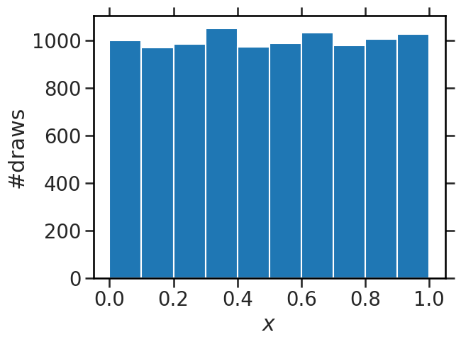

```python
plt.hist(results)
plt.xlabel('$x$')
plt.ylabel('#draws');
```

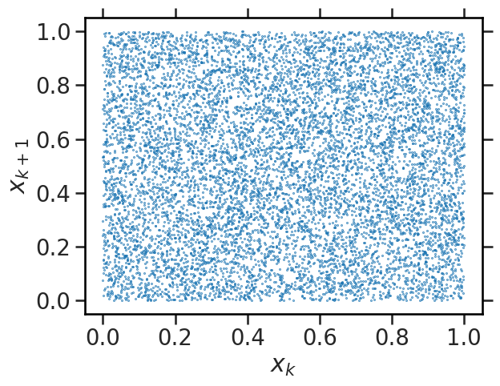

```python
plt.scatter(results[:-1], results[1:], s=1, marker='.')
plt.xlabel('$x_k$')
plt.ylabel('$x_{k+1}$');
```

$\implies$ what happens if you change the parameters $M,a,c$?  
Try e.g. $a=5$ or $M=2^{31}-2$...

## Generation of Gaussian Normal Distributed Pseudo-random Numbers

**Box-Muller Method**: Generate $x,y$ with bi-variate Gaussian normal probability density function $f(x,y)=\frac{1}{2\pi}e^{\frac{1}{2}\left(x^2 + y^2\right)}$ from uniformly distributed random numbers $\xi_1,\xi_2\in[0,1)$,

$$\begin{align} x &= \sqrt{-2\ln(\xi_2)}\,\cos(2\pi\xi_1) \\ y &= \sqrt{-2\ln(\xi_2)}\,\sin(2\pi\xi_1) \end{align}$$

which can be derived by **direct inversion** of the cumulative distribution function of $f$.

```python
prng_1 = RandomNumberGenerator(
    M=2**31 - 1,
    a=7**5,
    c=0,
    seed=12345)

prng_2 = RandomNumberGenerator(
    M=2**31 - 1,
    a=7**5,
    c=0,
    seed=42)
```

```python
def generate_normal():
    xi1 = prng_1.generate()
    xi2 = prng_1.generate()
    r = np.sqrt(-2 * np.log(xi2))
    x = r * np.cos(2 * np.pi * xi1)
    y = r * np.sin(2 * np.pi * xi1)
    return x, y
```

```python
results = np.array(
    [generate_normal() for i in range(10000)]
).flatten()
```

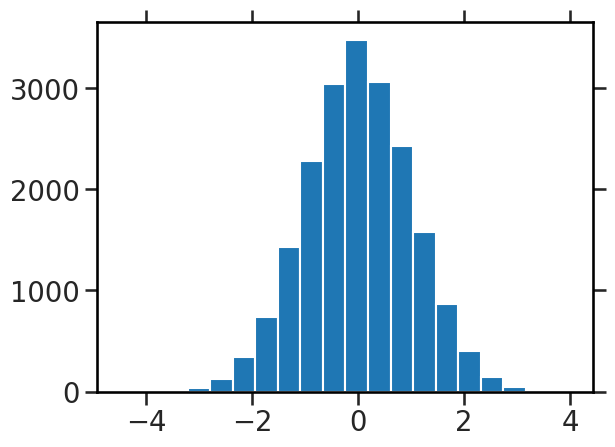

```python
plt.hist(results, bins=20);
```

## NumPy has it all...

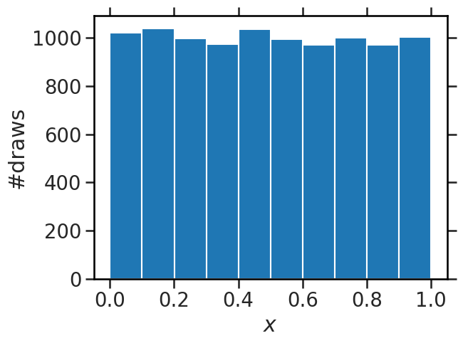

```python
plt.hist(np.random.random(size=10000));
plt.xlabel('$x$')
plt.ylabel('#draws');
```

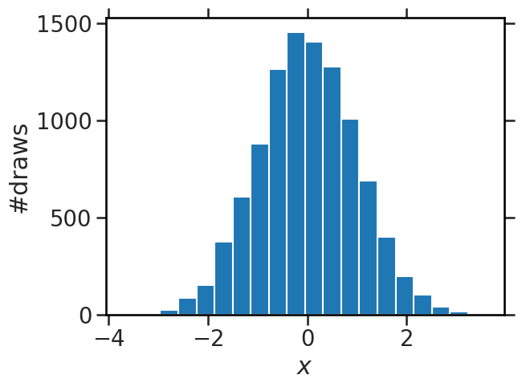

```python
plt.hist(np.random.normal(size=10000), bins=20);
plt.xlabel('$x$')
plt.ylabel('#draws');
```

## Part II: Hamiltonian for Longitudinal Dynamics

## Longitudinal Differential Equations

Longitudinal dynamics in a synchrotron is generally called **synchrotron motion**.

From the previous lecture we recover the one-turn **difference map** for longitudinal tracking:

$$\left\{\begin{array}\, z_{n+1} &= z_n - \eta C \left(\cfrac{\Delta p}{p_0}\right)_n \\ (\Delta p)_{n+1} &= (\Delta p)_n + \cfrac{q V}{(\beta c)_n}\cdot\left(\sin\left(\varphi_s - \cfrac{2\pi}{C}\cdot hz_{n+1}\right) - \sin(\varphi_s)\right) \end{array}\right.$$

Treat **adiabatic acceleration** case ($\beta=\mathrm{const}$ during rf cavity kick) in **smooth focusing approximation** (rf cavity effect all around the ring):

$\implies$ obtain **differential equations** via $z_{n+1}-z_n\leadsto \frac{dz}{ds}\cdot C$ and $\Delta p_{n+1}-\Delta p_n \leadsto \frac{d(\Delta p)}{ds}\cdot C$

$$\left\{\begin{array}\, \cfrac{dz}{ds} &= -\eta\cdot \cfrac{\Delta p}{p_0} \\ \cfrac{d(\Delta p)}{ds} &= \cfrac{q V}{C\beta c}\cdot \left(\sin\left(\varphi_s - \cfrac{2\pi}{C}\cdot hz\right) - \sin(\varphi_s)\right) \end{array}\right.$$

## The Hamiltonian of Synchrotron Motion

To find (a sort of "instantaneous") $\mathcal{H}(z,\Delta p)=T(\Delta p) + U(z)$ which is conserved only for const. $p_0,\beta,\gamma$, integrate Hamilton equations:

The first equation determines the kinetic energy term $T(\Delta p)$

$$\begin{align} \frac{dz}{ds} &\stackrel{!}{=} \frac{\partial \mathcal{H}}{\partial (\Delta p)} \\ \stackrel{\int}{\implies} \mathcal{H}(z,\Delta p) &= \underbrace{-\frac{1}{2}\frac{\eta}{p_0} \Delta p{}^2}\limits_{T} + U(z) + \mathrm{const.} \end{align}$$

and the second equation

$$\frac{d(\Delta p)}{ds} \stackrel{!}{=} -\frac{\partial\mathcal{H}}{\partial z}$$

determines the potential energy $U(z)$, such that the integration gives

the Hamiltonian of **synchrotron motion**:
$$ \mathcal{H}(z,\Delta p)=-\frac{1}{2}\frac{\eta}{p_0} \Delta p{}^2 - \frac{qV}{\beta c}\cdot\frac{1}{2\pi h}\left(\cos\left(\varphi_s - \frac{2\pi h}{C}\cdot z\right) - \frac{2\pi h}{C}\cdot z\cdot \sin(\varphi_s)\right) +\mathrm{const.}$$

## Stationary Case and Small-amplitude Approximation

For the stationary case $\sin(\varphi_s)=0$, we recover the **simple pendulum** Hamiltonian if $\varphi_s=0$ below or $\varphi_s=\pi$ above transition,

$$\mathcal{H}_\mathrm{stat}(z,\Delta p) = -\frac{1}{2}\frac{\eta}{p_0} {\color{red}{\Delta p{}^2}} +\frac{qV}{\beta c}\cdot\frac{1}{2\pi h}{\color{red}{\cos\left(\varphi_s - \frac{2\pi h}{C}\cdot z\right)}} $$

Remember, this expresses again the phase focusing requirement!

For small $z$ around the synchronous particle (stable fixed point!), develop $\cos(x)\approx x^2/2 + \mathcal{O}(x^4)$:

$$\mathcal{H}_\mathrm{stat,small}(z,\Delta p) = -\mathrm{sgn}(\eta)\cdot\left[\frac{1}{2}\frac{|\eta|}{p_0} {\color{red}{\Delta p{}^2}} + \frac{qV}{\beta c}\cdot \cfrac{\pi h}{C^2}\cdot {\color{red}{z^2}}\right] $$

$\implies$ Hamiltonian of harmonic oscillation!

## Synchrotron Tune

The small-amplitude case (small $z$) yields the linear oscillation frequency of the particles. Assemble the 2nd-order ODE from the two 1st-order coupled ODEs:

$$\frac{dz^2}{ds^2}+\frac{\eta q V}{p_0 \beta c C}\cdot \left(\underbrace{\sin\left(\varphi_s - \frac{2\pi}{C} h z\right)}\limits_{\mathop{=}\sin(\varphi_s)\cos\left(\frac{2\pi}{C}hz\right) - \cos(\varphi_s)\sin\left(\frac{2\pi}{C}hz\right)} - \sin(\varphi_s)\right) = 0$$

Linearising in $z$ gives

$$\sin\left(\varphi_s - \frac{2\pi}{C} h z\right) \approx \sin(\varphi_s) - \cos(\varphi_s)\cdot\frac{2\pi}{C} h z + \mathcal{O}(z^2)$$

and therefore the linearised ODE of 2nd order (harmonic oscillator ODE) reads

$$\frac{dz^2}{ds^2}+\underbrace{\frac{\eta q V 2\pi h \cos(\varphi_s)}{p_0 \beta c C^2}}\limits_{\mathop{=}\Omega_s^2}\cdot z = 0$$

and the **linear synchrotron tune** $Q_s$ (longitudinal oscillations per turn) evaluates to
$$Q_s^2=\frac{\omega_s^2}{\omega_\mathrm{rev}{}^2} = \frac{\Omega_s^2}{(2\pi/C)^2} = \frac{\eta h q V \cos(\varphi_s)}{2\pi p_0 \beta c}$$

## Visualisation by Tracking in CERN PS

We return to the material from the previous lecture, the CERN Proton Synchrotron (PS):

- has a circumference of 2π·100m
- takes protons from the PS Booster at a kinetic energy of 2GeV corresponding to a γ of 3.13
- injects with 50kV of rf voltage, up to 200kV for ramp
- runs at harmonic $h=7$
- has a momentum compaction factor of $\alpha_c=0.027$
- typical acceleration rate of (up to) $\dot{B}=2$ T/s, the bending radius is $\rho=70.08$ m

```python
def beta(gamma):
    '''Speed β in units of c from relativistic Lorentz factor γ.'''
    return np.sqrt(1 - gamma**-2)

def gamma(p):
    '''Relativistic Lorentz factor γ from total momentum p.'''
    return np.sqrt(1 + (p / (mass * c))**2)
```

Again, the `Machine` class representing the PS:

```python
charge = e
mass = m_p

class Machine(object):
    gamma_ref = 3.13
    circumference = 2 * np.pi * 100
    voltage = 200e3
    harmonic = 7
    alpha_c = 0.027
    phi_s = 0.456

    def __init__(self, gamma_ref=gamma_ref, circumference=circumference,
                 voltage=voltage, harmonic=harmonic,
                 alpha_c=alpha_c, phi_s=phi_s):
        '''Override default settings by giving explicit arguments.'''
        self.gamma_ref = gamma_ref
        self.circumference = circumference
        self.voltage = voltage
        self.harmonic = harmonic
        self.alpha_c = alpha_c
        self.phi_s = phi_s

    def eta(self, deltap):
        '''Phase-slip factor for a particle.'''
        p = self.p0() + deltap
        return self.alpha_c - gamma(p)**-2

    def p0(self):
        '''Momentum of synchronous particle.'''
        return self.gamma_ref * beta(self.gamma_ref) * mass * c

    def update_gamma_ref(self):
        '''Advance the energy of the synchronous particle
        according to the synchronous phase by one turn.
        '''
        deltap_per_turn = charge * self.voltage / (
            beta(self.gamma_ref) * c) * np.sin(self.phi_s)
        new_p0 = self.p0() + deltap_per_turn
        self.gamma_ref = gamma(new_p0)
```

```python
def track_one_turn(z_n, deltap_n, machine):
    m = machine
    # half drift
    z_nhalf = z_n - m.eta(deltap_n) * deltap_n / m.p0() * m.circumference / 2
    # rf kick
    amplitude = charge * m.voltage / (beta(gamma(m.p0())) * c)
    phi = m.phi_s - m.harmonic * 2 * np.pi * z_nhalf / m.circumference

    m.update_gamma_ref()
    deltap_n1 = deltap_n + amplitude * (np.sin(phi) - np.sin(m.phi_s))
    # half drift
    z_n1 = z_nhalf - m.eta(deltap_n1) * deltap_n1 / m.p0() * m.circumference / 2
    return z_n1, deltap_n1
```

You can override the default PS parameters by supplying arguments to the `Machine(...)` instantiation, e.g. change the `gamma_ref` by `m = Machine(gamma_ref=20)` or the `phi_s` etc.

```python
m = Machine()
```

Now we define the kinetic and potential energy terms and the Hamiltonian function(al) itself:

```python
def T(deltap, machine):
    '''Kinetic energy term in Hamiltonian.'''
    return -0.5 * machine.eta(deltap) / machine.p0() * deltap**2

def U(z, machine, beta_=None):
    '''Potential energy term in Hamiltonian.
    If beta is not given, compute it from synchronous particle.
    '''
    m = machine
    if beta_ is None:
        beta_ = beta(gamma(m.p0()))
    ampl = charge * m.voltage / (beta_ * c * 2 * np.pi * m.harmonic)
    phi = m.phi_s - 2 * np.pi * m.harmonic / m.circumference * z
    # convenience: define z at unstable fixed point
    z_ufp = -m.circumference * (np.pi - 2 * m.phi_s) / (2 * np.pi * m.harmonic)
    # convenience: offset by potential value at unstable fixed point
    # such that unstable fixed point (and separatrix) have 0 potential energy
    return ampl * (-np.cos(phi) +
                   2 * np.pi * m.harmonic / m.circumference * (z - z_ufp) * np.sin(m.phi_s) +
                   -np.cos(m.phi_s))
```

```python
def hamiltonian(z, deltap, machine):
    return T(deltap, machine) + U(z, machine, beta_=beta(gamma(machine.p0() + deltap)))
```

```python
def plot_hamiltonian(machine, zleft=-50, zright=50, dpmax=0.01, cbar=True):
    '''Plot Hamiltonian contours across (zleft, zright) and (-dpmax, dpmax).'''
    Z, DP = np.meshgrid(np.linspace(zleft, zright, num=1000),
                        np.linspace(-dpmax, dpmax, num=1000))
    H = hamiltonian(Z, DP * machine.p0(), machine) / machine.p0()

    plt.contourf(Z, DP, H, cmap=plt.get_cmap('hot_r'), levels=12,
                 zorder=0, alpha=0.5)
    plt.xlabel('$z$ [m]')
    plt.ylabel(r'$\delta$')
    if cbar:
        colorbar = plt.colorbar(label=r'$\mathcal{H}(z,\Delta p)\,/\,p_0$')
        colorbar.ax.axhline(0, lw=2, c='b')
    plt.contour(Z, DP, H, colors='b', linewidths=2, levels=[0])
```

Let's plot the Hamiltonian landscape on phase space:

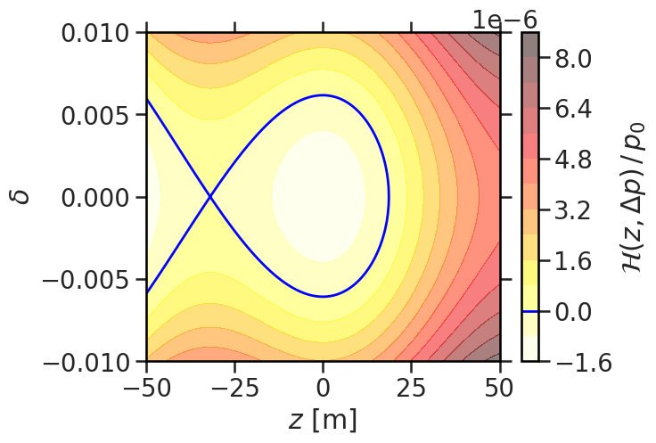

```python
plot_hamiltonian(m)
```

Tracking just like last lecture:

```python
n_turns = 500
deltap_ini = np.linspace(0, 0.01 * m.p0(), 20)
z_ini = np.zeros_like(deltap_ini)

N = len(z_ini)
assert (N == len(deltap_ini))
```

```python
z = np.zeros((n_turns, N), dtype=np.float64)
deltap = np.zeros_like(z)

z[0] = z_ini
deltap[0] = deltap_ini
```

Record the evolution of energy $\gamma_\mathrm{ref}$ and also Hamiltonian values of particles during tracking:

```python
gammas = np.zeros(n_turns, dtype=np.float64)
gammas[0] = m.gamma_ref

H_values = np.zeros_like(z)
H_values[0] = hamiltonian(z_ini, deltap_ini, m) / m.p0()
```

The tracking loop:

```python
for i_turn in range(1, n_turns):
    z[i_turn], deltap[i_turn] = track_one_turn(z[i_turn - 1], deltap[i_turn - 1], m)
    gammas[i_turn] = m.gamma_ref
    H_values[i_turn] = hamiltonian(z[i_turn], deltap[i_turn], m) / m.p0()
```

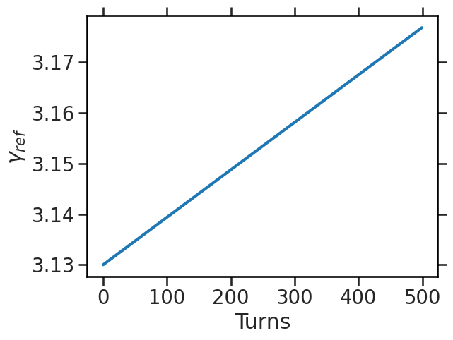

```python
plt.plot(gammas)
plt.xlabel('Turns')
plt.ylabel('$\gamma_{ref}$');
```

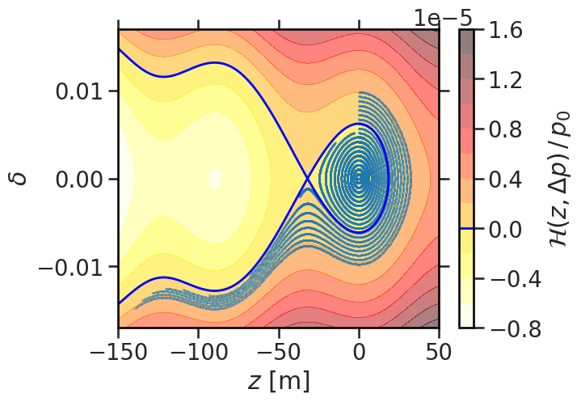

```python
plt.scatter(z, deltap / m.p0(), marker='.', s=0.5)
plt.xlabel('$z$ [m]')
plt.ylabel('$\Delta p/p_0$')
plot_hamiltonian(m, zleft=-150, zright=50, dpmax=0.017)
```

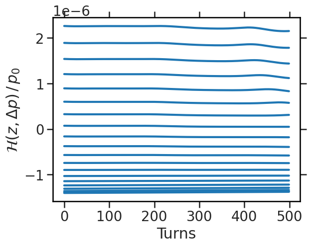

```python
plt.plot(H_values, c='C0');
plt.xlabel('Turns')
plt.ylabel(r'$\mathcal{H}(z,\Delta p)\,/\,p_0$');
```

```python
def plot_rf_overview():
    z_range = np.linspace(-150, 40, num=1000)
    # z location of unstable fixed point:
    z_ufp = -m.circumference * (np.pi - 2 * m.phi_s) / (2 * np.pi * m.harmonic)

    fig, ax = plt.subplots(3, 1, figsize=(6, 10), sharex=True)

    plt.sca(ax[0])
    plt.plot(z_range, 1e-3 * m.voltage * np.sin(m.phi_s - 2 * np.pi * m.harmonic / m.circumference * z_range))
    plt.axhline(0, c='gray', lw=2)
    plt.axhline(1e-3 * m.voltage * np.sin(m.phi_s), c='purple', lw=2, ls='--')
    plt.axvline(0, c='purple', lw=2)
    plt.axvline(z_ufp, c='red', lw=2)
    plt.ylabel('rf wave $V(z)$ [kV]')

    plt.sca(ax[1])
    plt.plot(z_range, 1e6 * U(z_range, m) / m.p0())
    plt.axhline(0, c='gray', lw=2)
    plt.ylabel(r'$U(z)\,/\,p_0\cdot 10^6$')

    plt.scatter([z_ufp], [0], marker='*', c='white', edgecolor='red', zorder=10)
    plt.scatter([0], [U(0, m) / m.p0()], marker='d', c='white', edgecolor='purple', zorder=10)

    plt.sca(ax[2])
    plot_hamiltonian(m, zleft=z_range[0], zright=z_range[-1], cbar=False)
    plt.scatter([z_ufp], [0], marker='*', c='white', edgecolor='red', zorder=10)
    plt.scatter([0], [0], marker='d', c='white', edgecolor='purple')
    plt.xlabel('$z$ [m]')
    plt.ylabel('$\delta$')
    plt.subplots_adjust(hspace=0)

    return fig, ax
```

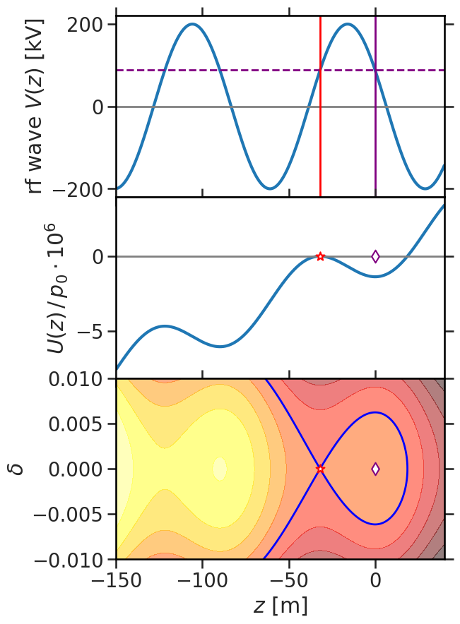

```python
plot_rf_overview();
```

$\implies$ the closed area inside the blue separatrix is typically referred to as **rf bucket**!

## Exercises based on Tracking

Modify the machine parameters and particle initial conditions to answer the following questions:

1. Do the Hamiltonian contours predict the tracked particle trajectories well?
2. Compare the stationary synchronous particle situation to the nonlinear pendulum: what is the meaning of the $\pi$ phase offset of $\varphi_s$ in terms of the pendulum? What state of the pendulum does the stable and what the unstable fixed point correspond to?
3. (if not already done last plenary session,) compute the transition energy $\gamma_\mathrm{t}$ of CERN PS
4. CERN PS accelerates protons from $\gamma=3.1$ up to $\gamma=27.7$. Is the transition energy crossed during acceleration? What does this mean for the setting of the synchronous phase $\varphi_s$ in the control room?
5. What happens to phase focusing at the transition energy $\gamma=\gamma_\mathrm{t}$? Can you explain why? (Think of the phase slippage mechanism.)

$\implies$ please make sure you understand and note down the answers to these questions (as discussed during the plenary session): the concepts are central to accelerator physics and relevant for the exam.

$\implies$ *"bonus": determine the synchrotron tune from tracking simulations (using NAFF) and compare to the derived formula for $Q_s$!*

## Part III: Initialisation of Phase Space for Longitudinal Simulations

## Equilibrium Distributions

Time-independent Hamiltonian system with bound states (state described by conjugate phase-space variables $q_i,p_i$ and the **periodic dynamics** by the Hamiltonian functional $\mathcal{H}=\mathcal{H}(q_i,p_i)$):

$\implies$ **equilibrium particle density functions** can be constructed in terms of the Hamiltonian $\mathcal{H}$:

$$\psi(z,\delta)=\psi(\mathcal{H})$$

"Equilibrium" $=$ no variation of $\psi$ along time parameter i.e. path length $s$

$$\frac{d\psi(\mathcal{H})}{ds} = \frac{d\psi}{d\mathcal{H}}\cdot \underbrace{\frac{d\mathcal{H}}{ds}}\limits_{\mathop{\equiv} 0}=0$$

## Typical Equilibrium Distribution Functions

In particle beam dynamics one often encounters these two equilibrium distribution functions:

1. **thermal distribution**:

$$\psi(\mathcal{H}) \propto \exp\left(\cfrac{\mathcal{H}}{\mathcal{H}_0}\right)$$

2. **waterbag distribution**:

$$\psi(\mathcal{H}) \propto \Theta\left(\mathcal{H}_0-\mathcal{H}\right) = \left\{\begin{array}\, 0 &,~\mathcal{H}\geq\mathcal{H}_0 \\ 1 &,~\mathcal{H}<\mathcal{H}_0 \end{array}\right.$$

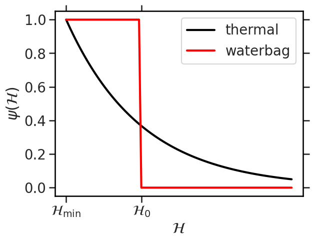

```python
h = np.linspace(0, 3, 100)

plt.plot(h, np.exp(-h), c='k', label='thermal')
plt.plot(h, np.heaviside(1 - h, 0), c='r', label='waterbag')
plt.xticks([0, 1], ['$\mathcal{H}_\mathrm{min}$', '$\mathcal{H}_0$'])
plt.legend()
plt.xlabel(r'$\mathcal{H}$')
plt.ylabel(r'$\psi(\mathcal{H})$');
```

## Equilibrium at Small Amplitudes

Let us start with the *small-amplitude approximation* and a stationary rf bucket below transition, $\varphi_s=0$: particles follow harmonic oscillation with

$$\mathcal{H}_\mathrm{stat,small}(z,\Delta p) = \frac{1}{2}\frac{-\eta}{p_0} \Delta p{}^2 + \frac{qV}{\beta c}\cdot \cfrac{\pi h}{C^2}\cdot z^2 $$

The PDF of the *thermal distribution* becomes

$$\psi(\mathcal{H})\propto\exp\left(\frac{\mathcal{H}_{stat,small}}{\mathcal{H}_0}\right)=\exp\left(\frac{1}{2}\frac{\frac{qV\,2\pi h}{\beta c C^2}}{\mathcal{H}_0}\cdot z^2\right) \cdot \exp\left(\frac{1}{2}\frac{-\eta/p_0}{\mathcal{H}_0}\cdot \Delta p^2\right)$$

which is simply a **bi-Gaussian distribution** in $\Delta p$ and $z$! The constant $\mathcal{H}_0$ is determined by a choice of the rms bunch length $\sigma_z$ (or equivalently the rms momentum deviation $\sigma_\delta=\sigma_{\Delta p}/p_0$):

$$\mathcal{H}_0 = \mathcal{H}_\mathrm{stat,small}(\sigma_z,\Delta p=0) = \frac{qV}{\beta c}\cdot \cfrac{\pi h}{C^2}\cdot \sigma_z{}^2 \color{red}{=} \mathcal{H}_\mathrm{stat,small}(z=0,\sigma_{\Delta p}) = \frac{1}{2}\frac{-\eta}{p_0} \sigma_{\Delta p}{}^2$$

$\implies$ as equilibrium condition, **$\sigma_z$ and $\sigma_\delta$ are linked** to each other via equal Hamiltonian values!

## Interactive Tracking

Initialise a bi-Gaussian distribution in the longitudinal phase-space plane for tracking!

Refer once more to the CERN PS scenario, below transition and in a stationary rf bucket:

```python
m = Machine(gamma_ref=3.13, phi_s=0)
```

The length of the rf bucket corresponds to $C/h$:

```python
m.circumference / m.harmonic
```

```
89.75979010256552
```

We choose an rms bunch length of $\sigma_z=10\,$m:

```python
sigma_z = 10
```

The corresponding rms momentum difference $\sigma_{\Delta p}$ is given through the equilibrium condition (equal Hamiltonian values):

```python
sigma_deltap = np.sqrt(
    2 * m.p0() / -m.eta(0) *
    charge * m.voltage * np.pi * m.harmonic / (beta(gamma(m.p0())) * c * m.circumference**2)
) * sigma_z
```

```python
sigma_dp = sigma_deltap / m.p0()
sigma_dp
```

```
0.0033548633698611986
```

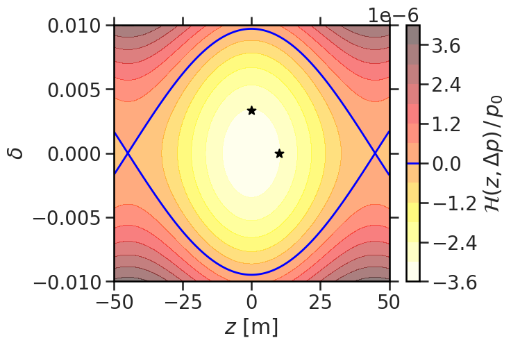

```python
plot_hamiltonian(m)
plt.scatter([sigma_z, 0], [0, sigma_dp], marker='*', c='k');
```

Back to tracking, out of the box:

```python
N = 1000
n_turns = 5000
```

```python
np.random.seed(12345)

z_ini = np.random.normal(loc=0, scale=sigma_z, size=N)
deltap_ini = np.random.normal(loc=0, scale=sigma_deltap, size=N)
```

```python
z = np.zeros((n_turns, N), dtype=np.float64)
deltap = np.zeros_like(z)

z[0] = z_ini
deltap[0] = deltap_ini
```

```python
for i_turn in trange(1, n_turns):
    z[i_turn], deltap[i_turn] = track_one_turn(z[i_turn - 1], deltap[i_turn - 1], m)
```

Now let's return to the outlined Monte-Carlo approach, analysing the results in terms of statistical moments.

First the centroid:

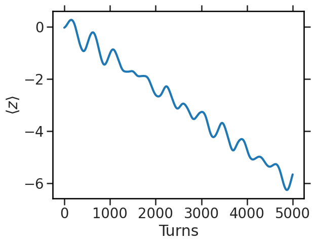

```python
plt.plot(np.mean(z, axis=1))

plt.xlabel('Turns')
plt.ylabel(r'$\langle z \rangle$');
```

Then the rms beam size (bunch length):

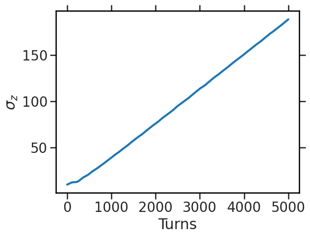

```python
plt.plot(np.std(z, axis=1))

plt.xlabel('Turns')
plt.ylabel(r'$\sigma_z$');
```

## What happened?

Let's look at the generated initial distribution of macro-particles:

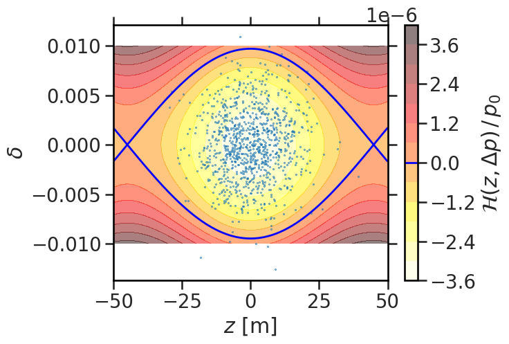

```python
plot_hamiltonian(m);
plt.scatter(z[0], deltap[0] / m.p0(), marker='.', s=1);
```

$\implies$ particles have been generated outside the rf bucket!

## Rejection Sampling Method

Solution to the problem of generating particles outside the separatrix: reject them at generation!

$\leadsto$ caution: this approach modifies the effective distribution function (and the correspondingly generated effective rms values $\sigma_z, \sigma_\delta$ become smaller)!

```python
np.random.seed(12345)

z_ini = np.random.normal(loc=0, scale=sigma_z, size=N)
deltap_ini = np.random.normal(loc=0, scale=sigma_deltap, size=N)
```

Hamiltonian values of particles outside separatrix are positive (below transition), $\mathcal{H}>0$ (using the full nonlinear Hamiltonian)!

Due to the discrete kicks in the finite difference maps, the Hamiltonian is only an approximation for the separatrix: better remain at a few percent distance inside of it!

```python
H_safetymargin = 0.05 * hamiltonian(0, 0, m)

H_values = hamiltonian(z_ini, deltap_ini, m) - H_safetymargin

while any(H_values >= 0):
    mask_bad = H_values >= 0
    N_bad = np.sum(mask_bad)
    print (N_bad)
    # re-initialise bad particles:
    z_ini[mask_bad] = np.random.normal(loc=0, scale=sigma_z, size=N_bad)
    deltap_ini[mask_bad] = np.random.normal(loc=0, scale=sigma_deltap, size=N_bad)
    # re-evaluate rejection condition
    H_values = hamiltonian(z_ini, deltap_ini, m) - H_safetymargin
```

```
14
```

Now we should be good to go!

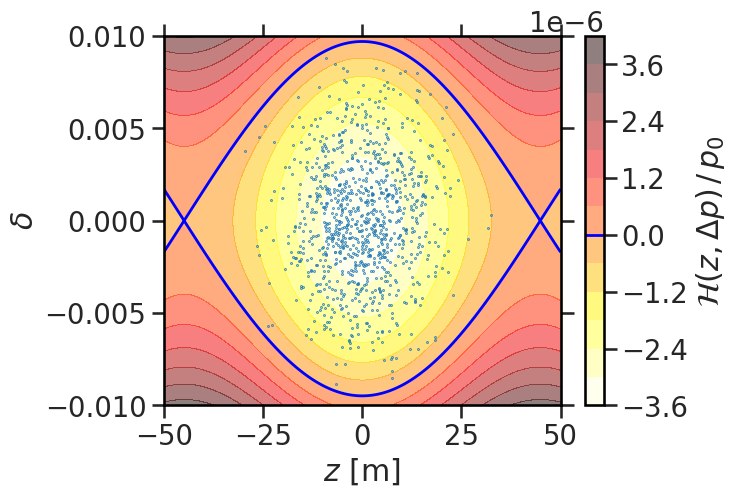

```python
plot_hamiltonian(m);
plt.scatter(z_ini, deltap_ini / m.p0(), marker='.', s=1);
```

Tracking again...

```python
z = np.zeros((n_turns, N), dtype=np.float64)
deltap = np.zeros_like(z)

z[0] = z_ini
deltap[0] = deltap_ini
```

```python
for i_turn in trange(1, n_turns):
    z[i_turn], deltap[i_turn] = track_one_turn(z[i_turn - 1], deltap[i_turn - 1], m)
```

Looking again at the centroid:

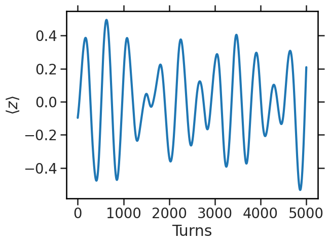

```python
plt.plot(np.mean(z, axis=1))

plt.xlabel('Turns')
plt.ylabel(r'$\langle z \rangle$');
```

Then the rms bunch length:

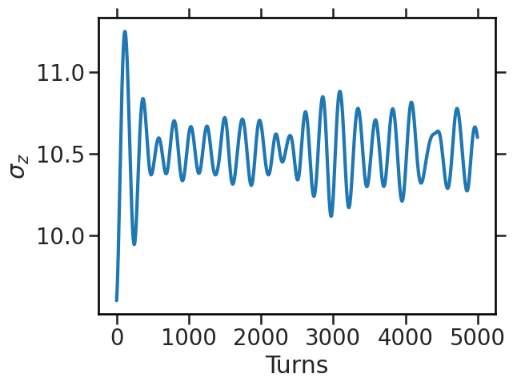

```python
plt.plot(np.std(z, axis=1))

plt.xlabel('Turns')
plt.ylabel(r'$\sigma_z$');
```

$\implies$ try larger choices of initial $\sigma_z$ and see where the bunch length evolution saturates.

$\leadsto$ another problem with initialising Gaussian distributions: at larger amplitudes $z$, the small-amplitude approximation with $\mathcal{H}_\mathrm{stat,small}$ necessarily breaks down! A Gaussian particle distribution is **not** in equilibrium for sufficiently large rms values in a nonlinear potential, the particles will **filament**! (...and the rms emittance will grow, as one can observe in the final equilibrium rms bunch length which is larger than the initial $\sigma_z$!)

$\implies$ require full nonlinear Hamiltonian to construct PDF $\psi(\mathcal{H})=\exp\left(\cfrac{\mathcal{H}}{\mathcal{H}_0}\right)$

## RMS Emittance

Define statistical **rms emittance** as in lecture 02:

```python
def emittance(z, deltap):
    N = len(z)

    # subtract centroids
    z = z - 1/N * np.sum(z)
    deltap = deltap - 1/N * np.sum(deltap)

    # compute Σ matrix entries
    z_sq = 1/N * np.sum(z * z)
    deltap_sq = 1/N * np.sum(deltap * deltap)
    crossterm = 1/N * np.sum(z * deltap)

    # determinant of Σ matrix
    epsilon = np.sqrt(z_sq * deltap_sq - crossterm * crossterm)
    return epsilon
```

```python
epsn_z = np.array([emittance(z_i, deltap_i) for z_i, deltap_i in zip(z, deltap)])
```

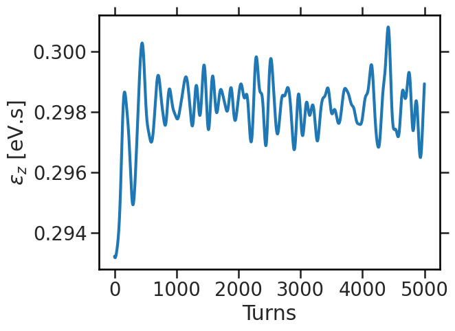

```python
plt.plot(epsn_z / e)

plt.xlabel('Turns')
plt.ylabel('$\epsilon_z$ [eV.s]');
```

$\implies$ try larger choices of initial $\sigma_z$ and observe how the emittance evolves.

## Summary

- Linear Congruential Generators: uniformly distributed random number sequences
- Box-Muller method: Gaussian distributed random number sequences
- Synchrotron motion: difference eq. $\rightarrow$ differential eq. $\rightarrow$ Hamiltonian $\mathcal{H}$
- rf bucket: the separatrix of synchrotron motion Hamiltonian
- relationship synchronous phase $\varphi_s$ vs. phase-slip factor $\eta$ vs. phase focusing vs. tracking & Hamiltonian
- harmonic oscillator and small-amplitude approximation
- equilibrium distributions and generation of macro-particles
- thermal PDF, connection of harmonic oscillation and bi-Gaussian distributions
- rejection sampling (rf bucket)

## Literature

- [J. Qiang's lecture on Monte-Carlo Simulation Techniques](https://arxiv.org/pdf/2006.10506.pdf)